# **GA-NLP Final Project: Customer Review Classification & Summarization**

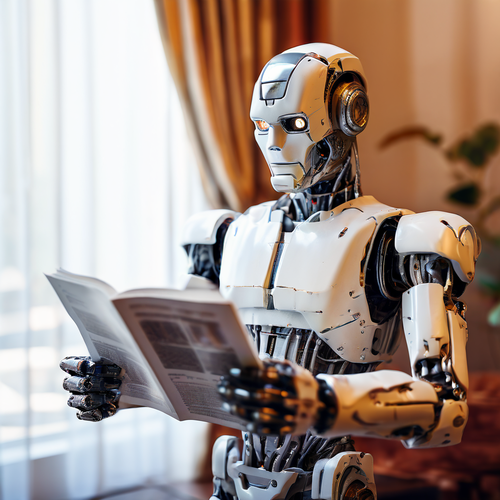

*Image generated with Playground-v2.5 on Poe*

## **Business Context**

In today's digital era, **customer reviews are pivotal for e-commerce platforms and online service providers**, serving as a barometer for customer satisfaction, highlighting areas for improvement, and guiding business decisions. The intricate process of Aspect-based Sentiment Analysis is instrumental in dissecting these reviews, offering a granular understanding of customer sentiments towards various facets of a product or service. This nuanced approach enables businesses to pinpoint specific elements—be it the screen, keyboard, or customer service of a laptop—that may need enhancement.

Moreover, the advent of Large Language Models (LLMs) has revolutionized the way businesses approach the summarization of customer reviews and case briefs. By leveraging LLMs, companies can swiftly and accurately distill the essence of customer feedback, streamlining the process of understanding overall sentiments and facilitating the refinement of product offerings. This swift synthesis not only conserves time and resources but also plays a critical role in enhancing customer satisfaction, driving sales, and boosting revenue.

Additionally, this project will delve into the **fine-tuning of models to elevate the quality of summaries provided by LLMs**. This involves training models on domain-specific data to enhance their ability to generate more precise and relevant summaries, thus improving the utility of these summaries in real-world applications.

Embarking on this final project on Customer Review Aspect-based Classification & Summarization, coupled with an emphasis on model fine-tuning for enhanced summarization, equips you with invaluable skills applicable to real-world business contexts. Through hands-on experience with code and implementation specifics, you'll gain the proficiency to construct such solutions using open-source LLMs. This experience will not only serve as a compelling Proof-of-Concept but also pave the way for the deployment and productionization of these cutting-edge solutions in business environments.

## **Project Objective**

We will use a Large Language Model to **automate the Aspect-based Classification and Summarization of Customer Reviews** received by a business. The project will aim to predict review sentiment, aspect-based sentiment and generate summaries of these customer reviews, and will evaluate the performance of the LLM at these tasks through various evaluation schemes.

## **Question 1: Install the Necessary Libraries (4 Marks)**

Important Note

This project is organized into two distinct sections:

1. Aspect-Based Sentiment Classification (24 Marks)
2. Parameter-Efficient Fine-Tuning and Evaluation (26 Marks)

**Each section can be completed independently, so you DO NOT need to run the entire notebook every time.**

### **Important Instructions**

You have a total of 8 hours of lab usage time to complete the project. This time cannot be extended.

If you need a break, you can pause the labs and resume later.

The labs will automatically pause after 20 minutes of inactivity.

To use your lab time effectively, download the notebook first and review the code before using your lab hours.

## **Part 1: Aspect Based Sentiment Classification**

### **1.1 Installation and Import (4 Marks)**

(A) Install necessary libraries (2 Marks)

(B) Import necessary libraries (2 Marks)

**1.1 (A) Install necessary libraries (2 Marks)**

```python
!apt-get update
!apt-get install -y ninja-build cmake
!pip install ipywidgets --upgrade
```

[output not shown]

[output cut: 33 more lines]

[output not shown]

[output not shown]

```python
import torch
```

```python
# This part of code will skip all the un-necessary warnings which can occur during the execution of this project.
import warnings
warnings.filterwarnings("ignore", category=Warning)
```

```python
# Installation for GPU llama-cpp-python==0.2.69
!CMAKE_ARGS="-DLLAMA_CUDA=on" pip install llama-cpp-python==0.2.69
!pip install rich
!pip install tqdm
# Installation for the huggingface-hub
!pip install huggingface_hub==0.23.2 -q
# installation for the datasets
!pip install -q datasets==3.0.0
```

[output not shown]

```python
!pip freeze>r.txt
```

```python
!nvidia-smi
```

```
Thu Apr 17 07:08:59 2025
+-----------------------------------------------------------------------------------------+
| NVIDIA-SMI 550.144.03             Driver Version: 550.144.03     CUDA Version: 12.4     |
|-----------------------------------------+------------------------+----------------------+
| GPU  Name                 Persistence-M | Bus-Id          Disp.A | Volatile Uncorr. ECC |
| Fan  Temp   Perf          Pwr:Usage/Cap |           Memory-Usage | GPU-Util  Compute M. |
|                                         |                        |               MIG M. |
|=========================================+========================+======================|
|   0  Tesla T4                       On  |   00000000:00:1E.0 Off |                    0 |
| N/A   22C    P8             12W /   70W |       1MiB /  15360MiB |      0%      Default |
|                                         |                        |                  N/A |
+-----------------------------------------+------------------------+----------------------+

+-----------------------------------------------------------------------------------------+
| Processes:                                                                              |
|  GPU   GI   CI        PID   Type   Process name                              GPU Memory |
|        ID   ID                                                               Usage      |
|=========================================================================================|
|  No running processes found                                                             |
+-----------------------------------------------------------------------------------------+
```

**1.1 (B) Import necessary libraries (2 Marks)**

```python
#  Import hf_hub_download from the huggingface_hub
from huggingface_hub import hf_hub_download
#  Import Llama from the llama_cpp library
from llama_cpp import Llama
# Import load_dataset from datasets
from datasets import load_dataset
```

```python
from sklearn.model_selection import train_test_split
from sklearn.metrics import f1_score
```

```python
import datasets
import pandas as pd
import numpy as np
import torch
```

```python
from tqdm import tqdm
```

```python
import json
import re
```

### **1.2 Model Setup (3 Marks)**

(A) Setup [model name](https://huggingface.co/TheBloke/Llama-2-13B-chat-GGUF) and base name (2 Marks)

(B) Create model path variable (1 Marks)

If the model loading process is taking longer than expected, try restarting the kernel and rerunning the notebook.

```python
# model name should be the "Llama-2-13B-chat-GGUF" from "TheBloke"
# model basename should be the Quantized model we want to use here - This should be the "Q5_K_M.gguf"

model_name = "TheBloke/Llama-2-13B-chat-GGUF"
model_basename = "llama-2-13b-chat.Q5_K_M.gguf" # the model is in gguf format
```

```python
model_path = hf_hub_download(
    repo_id = model_name,
    filename = model_basename
    )
```

```python
lcpp_llm = Llama(
        model_path=model_path,
        n_threads=2,  # CPU cores
        n_batch=512,  # Should be between 1 and n_ctx, consider the amount of VRAM in your GPU.
        n_gpu_layers=43,  # Change this value based on your model and your GPU VRAM pool.
        n_ctx=4096,  # Context window
    )
```

[output not shown]

[output cut: 42 more lines]

[output not shown]

### **1.3 Data Preparation (3 Marks)**

(A) Upload and read csv (1 Marks)

(B) Product Based DataFrame creation (2 Marks)

**1.3 (A) Upload and read csv (1 Marks)**

```python
sample_reviews_df = pd.read_csv("customer_reviews_dataset.csv")
```

```python
sample_reviews_df
```

|  | customer_id | customer_name | product_name | product_type | review_date | rating | review_sentiment | review_text | aspects_review | response | summary |
| --- | --- | --- | --- | --- | --- | --- | --- | --- | --- | --- | --- |
| 0 | CID041 | Aisha Patel | Dell Inspiron 15 | Laptop | 01/01/2024 | 5 | Positive | I bought this laptop for my son who is studyin... | { battery : Positive , keyboard : Positive, di... | It's fantastic to hear that the laptop you pur... | The user purchased a laptop for their son, who... |
| 1 | CID011 | Liam Thomson | JBL Tune 500BT | Headphones | 01/05/2024 | 1 | Negative | I was very disappointed with these headphones.... | { sound : Negative , comfort : Negative , char... | I'm truly sorry to hear about your disappointi... | The user expressed disappointment with poor so... |
| 2 | CID034 | Maria García | Mi Power Bank 3i | Power Bank | 01/10/2023 | 4 | Positive | Awesome power bank, it charges my phone very f... | { battery : Positive , charging : Positive } | Thank you for your positive review of our powe... | The user praises the power bank for its fast c... |
| 3 | CID032 | Jamal Johnson | Samsung Galaxy S21 | Smartphone | 03/03/2023 | 2 | Negative | I bought this phone mainly for its much-hyped ... | { display : Positive , camera : Negative , Bat... | I'm truly sorry to hear that the camera perfor... | The user expressed disappointment with the pho... |
| 4 | CID051 | Emily Nguyen | JBL Tune 500BT | Headphones | 05/25/2023 | 5 | Positive | I love these headphones, they are amazing. The... | { sound : Positive , comfort : Positive , char... | Thank you for your wonderful feedback on our h... | The user praises the headphones for their exce... |
| 5 | CID012 | Rafael Fernandez | Mi Power Bank 3i | Power Bank | 01/13/2024 | 1 | Negative | This is a very bad power bank, it does not cha... | { battery : Negative , charging : Negative } | I'm deeply concerned to hear about your experi... | The customer reviews a poor power bank, statin... |
| 6 | CID043 | Sofia Chen | Dell Inspiron 15 | Laptop | 05/20/2023 | 1 | Negative | I bought this laptop a month ago, and it's alr... | { battery : Negative , keyboard : Negative , d... | I'm sorry to hear about your laptop issues and... | The customer reports issues with their laptop,... |
| 7 | CID063 | Michael Lee | Dell Inspiron 15 | Laptop | 02/09/2023 | 2 | Negative | This is a below average laptop. It has inconsi... | { battery : Negative , keyboard : Negative , d... | I'm sorry to hear that your laptop isn't meeti... | The customer reviews a below-average laptop wi... |
| 8 | CID029 | Olivia Rodriguez | JBL Tune 500BT | Headphones | 01/02/2024 | 1 | Negative | I bought these headphones a week ago, and they... | { sound : Negative , comfort : Negative , char... | I apologize for the issues you're experiencing... | The customer purchased poor-quality headphones... |
| 9 | CID080 | Karan Singh | JBL Tune 500BT | Headphones | 02/22/2023 | 5 | Positive | These are the best headphones I have ever used... | { sound : Positive , comfort : Positive , char... | Thank you for sharing your positive experience... | The customer praises the headphones for their ... |
| 10 | CID007 | David Kim | Dell Inspiron 15 | Laptop | 05/03/2023 | 1 | Negative | I hate this laptop, it is a nightmare. I bough... | { battery : Negative , keyboard : Negative , d... | I'm truly sorry to hear about the difficulties... | The customer reviews a laptop with poor softwa... |
| 11 | CID040 | Reena Gupta | Mi Power Bank 3i | Power Bank | 10/02/2023 | 5 | Positive | Recently tried a power bank sharing service - ... | { battery : Positive , charging : Negative } | Thank you for your feedback on the power bank ... | The customer reviews a power bank sharing serv... |
| 12 | CID070 | Emre Çalhanoğlu | Samsung Galaxy S21 | Smartphone | 11/03/2023 | 2 | Negative | I am very unhappy with this phone, it has a ve... | { display : Negative , camera : Negative , Bat... | I'm truly sorry to hear about your dissatisfac... | The customer expresses dissatisfaction with th... |
| 13 | CID060 | Ketan Kopikar | JBL Tune 500BT | Headphones | 01/06/2024 | 2 | Negative | I bought these headphones just 2 weeks ago, an... | { sound : Negative , comfort : Negative , char... | I'm sorry to hear about your negative experien... | The customer is unhappy with their headphones,... |
| 14 | CID004 | Bradley Wiggins | Dell Inspiron 15 | Laptop | 05/10/2024 | 5 | Positive | This is a great laptop, I am very happy with i... | { battery : Positive , keyboard : Positive , d... | Thank you for your positive feedback on our la... | The customer is satisfied with their laptop, s... |
| 15 | CID100 | Milad Hosseini | Mi Power Bank 3i | Power Bank | 07/17/2023 | 4 | Positive | This is a good power bank, it does what it say... | { battery : Positive , charging : Positive } | Thank you for sharing your positive experience... | The customer praises the power bank for its ef... |
| 16 | CID030 | Rachel Smith | Samsung Galaxy S21 | Smartphone | 08/28/2023 | 4 | Positive | Good phone, I am satisfied with it. The phone ... | { display : Positive , camera : Positive , Bat... | Thank you for your positive review of the phon... | The customer is satisfied with their phone, pr... |
| 17 | CID010 | Miora Fimanantsoa | JBL Tune 500BT | Headphones | 12/12/2023 | 4 | Positive | The headphones work well. The sound quality is... | { sound : Positive , comfort : Positive , char... | Thank you for your review of our headphones. I... | The customer praises the headphones for their ... |
| 18 | CID078 | Nisha Sharma | Dell Inspiron 15 | Laptop | 06/12/2023 | 2 | Negative | I bought this laptop quite recently, and I alr... | { battery : Positive , keyboard : Positive, di... | I'm sorry to hear about the issues you're expe... | The customer is unhappy with their recently pu... |
| 19 | CID087 | Zulmi Virmansyah | Samsung Galaxy S21 | Smartphone | 05/27/2023 | 2 | Negative | Bought this phone because I wanted to upgrade ... | { display : Negative , camera : Positive , Bat... | I'm sorry to hear about your disappointment wi... | The customer purchased a phone to upgrade from... |
| 20 | CID027 | Kim Jung | Samsung Galaxy S21 | Smartphone | 09/28/2023 | 5 | Positive | Amazing phone. It has a beautiful design and a... | { display : Negative , camera : Positive , Bat... | Thank you for your enthusiastic review of the ... | The customer praises the phone's design, perfo... |
| 21 | CID085 | Manuela Marin | JBL Tune 500BT | Headphones | 10/01/2023 | 1 | Negative | I was very excited to get these headphones as ... | { sound : Negative , comfort : Negative , char... | I'm truly sorry to hear about your disappointi... | The customer was disappointed with their headp... |
| 22 | CID076 | Amit Shah | Mi Power Bank 3i | Power Bank | 03/02/2023 | 1 | Negative | This is a very poor power bank, it does not wo... | { battery : Negative , charging : Negative } | I'm sorry to hear about your dissatisfaction w... | The customer is dissatisfied with their power ... |
| 23 | CID075 | Jack Ryder | JBL Tune 500BT | Headphones | 05/05/2023 | 5 | Positive | Great for listening to music or podcasts. Good... | { sound : Positive , comfort : Positive , char... | Thank you for your positive review of our head... | Customer praises headphones for good sound qua... |
| 24 | CID046 | Harvey Stark | Mi Power Bank 3i | Power Bank | 07/19/2023 | 5 | Positive | I love this power bank - it's amazing. It can ... | { battery : Positive , charging : Positive } | Thank you for your enthusiastic feedback on ou... | The customer praises the power bank's capacity... |
| 25 | CID013 | Ollie Stone | JBL Tune 500BT | Headphones | 12/09/2023 | 1 | Negative | I bought these headphones as a wireless option... | { sound : Negative , comfort : Negative , char... | I'm sorry to hear about your unsatisfactory ex... | The customer returned their wireless headphone... |
| 26 | CID067 | Adewale Akinfenwa | Dell Inspiron 15 | Laptop | 01/09/2024 | 4 | Positive | The laptop is good enough for the price. It ha... | { battery : Positive , keyboard : Positive , d... | Thank you for sharing your thoughts on our lap... | The customer praises the laptop's performance,... |
| 27 | CID053 | Pooja Jain | Dell Inspiron 15 | Laptop | 12/31/2023 | 4 | Positive | Originally bought it for my work, quite happy ... | { battery : Positive , keyboard : Positive , d... | Thank you for sharing your positive experience... | The customer is satisfied with their work lapt... |
| 28 | CID082 | Laura Wolvaardt | Mi Power Bank 3i | Power Bank | 04/13/2023 | 4 | Positive | Good backup for my phone & other devices. Smal... | { battery : Positive , charging : Positive } | Thank you for your positive feedback on our po... | The customer praises the compact, lightweight ... |
| 29 | CID099 | Jim Kowalski | Dell Inspiron 15 | Laptop | 08/03/2023 | 1 | Negative | I thought this would be the laptop I could use... | { battery : Negative , keyboard : Negative , d... | I'm sorry to hear about the issues you're expe... | The customer regrets their purchase of a slow,... |

**1.3 (B) Product Based DataFrame creation (2 Marks)**

```python
# Create a "Laptop" reviews DataFrame based on the "product_type" column in the dataset
laptop_reviews = sample_reviews_df[sample_reviews_df['product_type'] == 'Laptop']

# Create a "Headphones" reviews DataFrame based on the "product_type" column in the dataset
headphones_reviews = sample_reviews_df[sample_reviews_df['product_type'] == 'Headphones']

# Create a "Smartphone" reviews DataFrame based on the "product_type" column in the dataset
smartphone_reviews = sample_reviews_df[sample_reviews_df['product_type'] == 'Smartphone']

# Create a "Power Bank" reviews DataFrame based on the "product_type" column in the dataset
power_bank_reviews = sample_reviews_df[sample_reviews_df['product_type'] == 'Power Bank']
```

```python
#laptop_gold_examples = laptop_reviews.sample(2, random_state=40)
#headphones_gold_examples = headphones_reviews.sample(2, random_state=40)
#smartphone_gold_examples = smartphone_reviews.sample(2, random_state=40)
#power_bank_gold_examples = power_bank_reviews.sample(2, random_state=40)

# Select one positive and one negative review for each category
laptop_gold_examples = pd.concat([
    laptop_reviews[laptop_reviews['review_sentiment'] == 'Positive'].head(1),
    laptop_reviews[laptop_reviews['review_sentiment'] == 'Negative'].head(1)
])

headphones_gold_examples = pd.concat([
    headphones_reviews[headphones_reviews['review_sentiment'] == 'Positive'].head(1),
    headphones_reviews[headphones_reviews['review_sentiment'] == 'Negative'].head(1)
])

smartphone_gold_examples = pd.concat([
    smartphone_reviews[smartphone_reviews['review_sentiment'] == 'Positive'].head(1),
    smartphone_reviews[smartphone_reviews['review_sentiment'] == 'Negative'].head(1)
])

power_bank_gold_examples = pd.concat([
    power_bank_reviews[power_bank_reviews['review_sentiment'] == 'Positive'].head(1),
    power_bank_reviews[power_bank_reviews['review_sentiment'] == 'Negative'].head(1)
])

# Concatenate positive and negative gold examples
sample_reviews_gold_examples_df = pd.concat([laptop_gold_examples, headphones_gold_examples,
                                             smartphone_gold_examples,power_bank_gold_examples])

# Create the training set by excluding gold examples
sample_reviews_examples_df = sample_reviews_df.drop(index=sample_reviews_gold_examples_df.index)

# Convert gold examples to JSON
columns_to_select = ['review_text', 'product_type','aspects_review']
gold_examples_json = sample_reviews_gold_examples_df[columns_to_select].to_json(orient='records')

# Print the first record from the JSON
print(json.loads(gold_examples_json)[0])

# Print the shapes of the datasets
print("Training Set Shape:", sample_reviews_examples_df.shape)
print("Gold Examples Shape:", sample_reviews_gold_examples_df.shape)
```

```
{'review_text': 'I bought this laptop for my son who is studying engineering. He is very happy with it. It has a good battery life, fast performance, and a sleek design. The keyboard is comfortable and the screen is bright. The laptop came with a one-year warranty and a free antivirus software. I th…
Training Set Shape: (22, 11)
Gold Examples Shape: (8, 11)
```

```python
sample_reviews_gold_examples_df
```

|  | customer_id | customer_name | product_name | product_type | review_date | rating | review_sentiment | review_text | aspects_review | response | summary |
| --- | --- | --- | --- | --- | --- | --- | --- | --- | --- | --- | --- |
| 0 | CID041 | Aisha Patel | Dell Inspiron 15 | Laptop | 01/01/2024 | 5 | Positive | I bought this laptop for my son who is studyin... | { battery : Positive , keyboard : Positive, di... | It's fantastic to hear that the laptop you pur... | The user purchased a laptop for their son, who... |
| 6 | CID043 | Sofia Chen | Dell Inspiron 15 | Laptop | 05/20/2023 | 1 | Negative | I bought this laptop a month ago, and it's alr... | { battery : Negative , keyboard : Negative , d... | I'm sorry to hear about your laptop issues and... | The customer reports issues with their laptop,... |
| 4 | CID051 | Emily Nguyen | JBL Tune 500BT | Headphones | 05/25/2023 | 5 | Positive | I love these headphones, they are amazing. The... | { sound : Positive , comfort : Positive , char... | Thank you for your wonderful feedback on our h... | The user praises the headphones for their exce... |
| 1 | CID011 | Liam Thomson | JBL Tune 500BT | Headphones | 01/05/2024 | 1 | Negative | I was very disappointed with these headphones.... | { sound : Negative , comfort : Negative , char... | I'm truly sorry to hear about your disappointi... | The user expressed disappointment with poor so... |
| 16 | CID030 | Rachel Smith | Samsung Galaxy S21 | Smartphone | 08/28/2023 | 4 | Positive | Good phone, I am satisfied with it. The phone ... | { display : Positive , camera : Positive , Bat... | Thank you for your positive review of the phon... | The customer is satisfied with their phone, pr... |
| 3 | CID032 | Jamal Johnson | Samsung Galaxy S21 | Smartphone | 03/03/2023 | 2 | Negative | I bought this phone mainly for its much-hyped ... | { display : Positive , camera : Negative , Bat... | I'm truly sorry to hear that the camera perfor... | The user expressed disappointment with the pho... |
| 2 | CID034 | Maria García | Mi Power Bank 3i | Power Bank | 01/10/2023 | 4 | Positive | Awesome power bank, it charges my phone very f... | { battery : Positive , charging : Positive } | Thank you for your positive review of our powe... | The user praises the power bank for its fast c... |
| 5 | CID012 | Rafael Fernandez | Mi Power Bank 3i | Power Bank | 01/13/2024 | 1 | Negative | This is a very bad power bank, it does not cha... | { battery : Negative , charging : Negative } | I'm deeply concerned to hear about your experi... | The customer reviews a poor power bank, statin... |

```python
gold_examples = (
        sample_reviews_gold_examples_df.loc[:, columns_to_select]
                                     .sample(8, random_state=40) #<- ensures that gold examples are the same for every session
                                     .to_json(orient='records')
)
```

### **1.4 Derive Prompt (7 Marks)**

1.4 (A) Create a Few Shot System Message (5 Marks)

1.4 (B) Combine user_prompt and system_message to create the prompt (2 Marks)

The functions that we used to assemble examples, create prompts and to evaluate these prompts are broadly the same as in the case of sentiment analysis. However, we should adapt the few-shot examples to now account for the multiple aspects.

**1.4 (A) Create a Few Shot System Message (5 Marks)**

**Instruction for System Message:**

Instruct the model to perform classification on reviews (input delimited by ```) by identifying one of four product types (Laptop, Headphones, Power Bank, Smartphone).

**For each product:**

**Assign a sentiment ("Positive" or "Negative") to the predefined aspects:** Laptop: battery, keyboard, display Headphones: sound, comfort, charging Power Bank: battery, charging Smartphone: display, camera, battery Output format must match:

**Example:** [ Laptop : { battery : ..., keyboard : ..., display : ... } ]

````python
few_shot_system_message = """
You are a review classification assistant. Analyze the product review provided inside triple backticks and
return correct product type and sentiments for their associated aspects.

Product type can only be one of [Laptop, Headphones, Power Bank, Smartphone]

The sentiment should be either "positive" or "negative" for the relevant aspects of that product.

Strictly use only the below aspect options for each product type. Do not add more than what is mentioned here.

[Laptop: battery, keyboard, display]
[Headphones: sound, comfort, charging]
[Power Bank: battery, charging]
[Smartphone: display, camera, battery]

Answer only 'positive' or 'negative' for each aspect. Do not explain your answer.

Your response must strictly follow this format and include nothing else:

[ ProductType : { aspect1 : Sentiment, aspect2 : Sentiment, ... } ]

 STRICT RULES:
- Do NOT wrap your answer in triple backticks (```)
- Do NOT use markdown, bullet points, or comments
- Do NOT add any extra text or explanation
- Capitalize the **product type** (e.g., Power Bank)
- Capitalize all **sentiment values** exactly as: Positive, Negative
- Ensure the output starts with `[` and ends with `]`
"""
````

**1.4 (B) Combine user_prompt and system_message to create the prompt (2 Marks)**

````python
def generate_llama_response( system_message ,  few_shot_examples  , new_review , temp ):

    # Combine user_prompt and system_message to create the prompt
    prompt = f"[INST] <<SYS>> \n {system_message} \n <</SYS>> \n ```{few_shot_examples}``` /n [/INST]\n [INST] \n {'user'}: ```{user_message_template.format(review=new_review)}```[/INST]"

    # Generate a response from the LLM model
    response = lcpp_llm(
        prompt=prompt,
        max_tokens=256,
        temperature=temp,
        top_p=0.95,
        repeat_penalty=1.2,
        top_k=50,
        stop=['INST'],
        echo=False
    )

    # Extract and return the response text
    response_text = response["choices"][0]["text"]
    return response_text
````

```python
def create_examples_with_seed(dataset, n=2, random_seed=None):
    """
    Return two DataFrames with randomized examples of size 2n with two classes.
    Create subsets of each class, choose random samples from the subsets,
    merge and randomize the order of samples in the merged list.
    Each run of this function creates a different random sample of examples
    chosen from the training data.

    Args:
        dataset (DataFrame): A DataFrame with examples (text + label)
        n (int): number of examples of each class to be selected
        random_seed (int): seed for reproducibility (default is None)

    Output:
        few_shot_examples_df (DataFrame): A DataFrame with examples in random order
        new_df (DataFrame): A new DataFrame excluding selected examples
    """

    laptop_reviews = (dataset.product_type == 'Laptop')
    headphone_reviews = (dataset.product_type == 'Headphones')
    power_bank_reviews = (dataset.product_type == 'Power Bank')
    smartphone_reviews = (dataset.product_type == 'Smartphone')
    columns_to_select = ['review_text', 'product_type','aspects_review']

    # Set a fixed random seed for reproducibility
    np.random.seed(random_seed)

    laptop_examples = dataset.loc[laptop_reviews, columns_to_select].sample(n)
    headphone_examples = dataset.loc[headphone_reviews, columns_to_select].sample(n)
    power_bank_examples = dataset.loc[power_bank_reviews, columns_to_select].sample(n)
    smartphone_examples = dataset.loc[smartphone_reviews, columns_to_select].sample(n)

    few_shot_examples_df = pd.concat([laptop_examples, headphone_examples, power_bank_examples, smartphone_examples])

    # sampling without replacement is equivalent to random shuffling
    few_shot_examples_df = few_shot_examples_df.sample( 4*n, replace=False)

    # Create a new DataFrame excluding selected examples
    new_df = dataset.drop(index=few_shot_examples_df.index)

    return few_shot_examples_df, new_df
```

```python
def compute_combined_aspect_and_product_accuracy(df):
    correct_predictions_count = 0

    # Function to parse aspect-based sentiment string into a dictionary
    def parse_aspects(aspect_string):
        aspect_string= str(aspect_string)
        aspect_string = re.sub(r'[{}]', '', aspect_string)  # Remove curly braces
        aspects = re.split(r',\s*', aspect_string)  # Split into individual aspects

        try:
         dict_res = dict(re.split(r'\s*:\s*', aspect) for aspect in aspects if aspect)
        except:
          dict_res={}

        return dict_res


    # Function to normalize text by removing spaces and converting to lowercase
    def normalize_text(text):
        return ''.join(text.split()).lower() if text is not None else None

    # Iterate over each row to compare product type and aspect-based sentiments
    for index, row in df.iterrows():
        predicted_product_type = normalize_text(row['predicted_product_type'])
        actual_product_type = normalize_text(row['product_type'])
        predicted_aspects = parse_aspects(row['predicted_aspect_based_sentiment'])
        actual_aspects = parse_aspects(row['aspects_review'])

        # Check if product type matches and all aspects match in sentiment
        if predicted_product_type == actual_product_type and \
          predicted_aspects != '' and \
          all(predicted_aspects.get(key, '').lower() == value.lower() for key, value in actual_aspects.items()):
            correct_predictions_count += 1

    # Calculate accuracy
    accuracy = (correct_predictions_count / len(df)) * 100
    return accuracy
```

### **1.5 Measuring prompt performance (7 Marks)**

1.5 (A) Generate response and compute accuracy (5 Marks)

1.5 (B) Evaluate the results (2 marks)

```python
user_message_template = "{review}"
```

```python
def extract_product_type(text):
    text=str(text)
    match = re.search(r'\[([^:]+)', text)
    return match.group(1).strip() if match else None

def extract_aspect_based_sentiment(text):
    text=str(text)
    match = re.search(r'\{([^}]+)\}', text)
    return "{ " + match.group(1).strip() + " }" if match else None
```

```python
accuracy_list = []
```

```python
sample_reviews_examples_df
```

|  | customer_id | customer_name | product_name | product_type | review_date | rating | review_sentiment | review_text | aspects_review | response | summary |
| --- | --- | --- | --- | --- | --- | --- | --- | --- | --- | --- | --- |
| 7 | CID063 | Michael Lee | Dell Inspiron 15 | Laptop | 02/09/2023 | 2 | Negative | This is a below average laptop. It has inconsi... | { battery : Negative , keyboard : Negative , d... | I'm sorry to hear that your laptop isn't meeti... | The customer reviews a below-average laptop wi... |
| 8 | CID029 | Olivia Rodriguez | JBL Tune 500BT | Headphones | 01/02/2024 | 1 | Negative | I bought these headphones a week ago, and they... | { sound : Negative , comfort : Negative , char... | I apologize for the issues you're experiencing... | The customer purchased poor-quality headphones... |
| 9 | CID080 | Karan Singh | JBL Tune 500BT | Headphones | 02/22/2023 | 5 | Positive | These are the best headphones I have ever used... | { sound : Positive , comfort : Positive , char... | Thank you for sharing your positive experience... | The customer praises the headphones for their ... |
| 10 | CID007 | David Kim | Dell Inspiron 15 | Laptop | 05/03/2023 | 1 | Negative | I hate this laptop, it is a nightmare. I bough... | { battery : Negative , keyboard : Negative , d... | I'm truly sorry to hear about the difficulties... | The customer reviews a laptop with poor softwa... |
| 11 | CID040 | Reena Gupta | Mi Power Bank 3i | Power Bank | 10/02/2023 | 5 | Positive | Recently tried a power bank sharing service - ... | { battery : Positive , charging : Negative } | Thank you for your feedback on the power bank ... | The customer reviews a power bank sharing serv... |
| 12 | CID070 | Emre Çalhanoğlu | Samsung Galaxy S21 | Smartphone | 11/03/2023 | 2 | Negative | I am very unhappy with this phone, it has a ve... | { display : Negative , camera : Negative , Bat... | I'm truly sorry to hear about your dissatisfac... | The customer expresses dissatisfaction with th... |
| 13 | CID060 | Ketan Kopikar | JBL Tune 500BT | Headphones | 01/06/2024 | 2 | Negative | I bought these headphones just 2 weeks ago, an... | { sound : Negative , comfort : Negative , char... | I'm sorry to hear about your negative experien... | The customer is unhappy with their headphones,... |
| 14 | CID004 | Bradley Wiggins | Dell Inspiron 15 | Laptop | 05/10/2024 | 5 | Positive | This is a great laptop, I am very happy with i... | { battery : Positive , keyboard : Positive , d... | Thank you for your positive feedback on our la... | The customer is satisfied with their laptop, s... |
| 15 | CID100 | Milad Hosseini | Mi Power Bank 3i | Power Bank | 07/17/2023 | 4 | Positive | This is a good power bank, it does what it say... | { battery : Positive , charging : Positive } | Thank you for sharing your positive experience... | The customer praises the power bank for its ef... |
| 17 | CID010 | Miora Fimanantsoa | JBL Tune 500BT | Headphones | 12/12/2023 | 4 | Positive | The headphones work well. The sound quality is... | { sound : Positive , comfort : Positive , char... | Thank you for your review of our headphones. I... | The customer praises the headphones for their ... |
| 18 | CID078 | Nisha Sharma | Dell Inspiron 15 | Laptop | 06/12/2023 | 2 | Negative | I bought this laptop quite recently, and I alr... | { battery : Positive , keyboard : Positive, di... | I'm sorry to hear about the issues you're expe... | The customer is unhappy with their recently pu... |
| 19 | CID087 | Zulmi Virmansyah | Samsung Galaxy S21 | Smartphone | 05/27/2023 | 2 | Negative | Bought this phone because I wanted to upgrade ... | { display : Negative , camera : Positive , Bat... | I'm sorry to hear about your disappointment wi... | The customer purchased a phone to upgrade from... |
| 20 | CID027 | Kim Jung | Samsung Galaxy S21 | Smartphone | 09/28/2023 | 5 | Positive | Amazing phone. It has a beautiful design and a... | { display : Negative , camera : Positive , Bat... | Thank you for your enthusiastic review of the ... | The customer praises the phone's design, perfo... |
| 21 | CID085 | Manuela Marin | JBL Tune 500BT | Headphones | 10/01/2023 | 1 | Negative | I was very excited to get these headphones as ... | { sound : Negative , comfort : Negative , char... | I'm truly sorry to hear about your disappointi... | The customer was disappointed with their headp... |
| 22 | CID076 | Amit Shah | Mi Power Bank 3i | Power Bank | 03/02/2023 | 1 | Negative | This is a very poor power bank, it does not wo... | { battery : Negative , charging : Negative } | I'm sorry to hear about your dissatisfaction w... | The customer is dissatisfied with their power ... |
| 23 | CID075 | Jack Ryder | JBL Tune 500BT | Headphones | 05/05/2023 | 5 | Positive | Great for listening to music or podcasts. Good... | { sound : Positive , comfort : Positive , char... | Thank you for your positive review of our head... | Customer praises headphones for good sound qua... |
| 24 | CID046 | Harvey Stark | Mi Power Bank 3i | Power Bank | 07/19/2023 | 5 | Positive | I love this power bank - it's amazing. It can ... | { battery : Positive , charging : Positive } | Thank you for your enthusiastic feedback on ou... | The customer praises the power bank's capacity... |
| 25 | CID013 | Ollie Stone | JBL Tune 500BT | Headphones | 12/09/2023 | 1 | Negative | I bought these headphones as a wireless option... | { sound : Negative , comfort : Negative , char... | I'm sorry to hear about your unsatisfactory ex... | The customer returned their wireless headphone... |
| 26 | CID067 | Adewale Akinfenwa | Dell Inspiron 15 | Laptop | 01/09/2024 | 4 | Positive | The laptop is good enough for the price. It ha... | { battery : Positive , keyboard : Positive , d... | Thank you for sharing your thoughts on our lap... | The customer praises the laptop's performance,... |
| 27 | CID053 | Pooja Jain | Dell Inspiron 15 | Laptop | 12/31/2023 | 4 | Positive | Originally bought it for my work, quite happy ... | { battery : Positive , keyboard : Positive , d... | Thank you for sharing your positive experience... | The customer is satisfied with their work lapt... |
| 28 | CID082 | Laura Wolvaardt | Mi Power Bank 3i | Power Bank | 04/13/2023 | 4 | Positive | Good backup for my phone & other devices. Smal... | { battery : Positive , charging : Positive } | Thank you for your positive feedback on our po... | The customer praises the compact, lightweight ... |
| 29 | CID099 | Jim Kowalski | Dell Inspiron 15 | Laptop | 08/03/2023 | 1 | Negative | I thought this would be the laptop I could use... | { battery : Negative , keyboard : Negative , d... | I'm sorry to hear about the issues you're expe... | The customer regrets their purchase of a slow,... |

**1.5 (A) Generate response and compute accuracy (5 Marks)**

```python
for i in range(3):
    few_shot_examples_df, sample_reviews_df = create_examples_with_seed(sample_reviews_examples_df, n=1 , random_seed = i)

    review_example1 = few_shot_examples_df.iloc[0].review_text
    review_example2 = few_shot_examples_df.iloc[1].review_text
    review_example3 = few_shot_examples_df.iloc[2].review_text
    review_example4 = few_shot_examples_df.iloc[3].review_text

    assistant_output_example1 = "[ " + few_shot_examples_df.iloc[0].product_type.lower() + " : " + few_shot_examples_df.iloc[0].aspects_review.lower() + " ]"
    assistant_output_example2 = "[ " + few_shot_examples_df.iloc[1].product_type.lower() + " : " + few_shot_examples_df.iloc[1].aspects_review.lower() + " ]"
    assistant_output_example3 = "[ " + few_shot_examples_df.iloc[2].product_type.lower() + " : " + few_shot_examples_df.iloc[2].aspects_review.lower() + " ]"
    assistant_output_example4 = "[ " + few_shot_examples_df.iloc[3].product_type.lower() + " : " + few_shot_examples_df.iloc[3].aspects_review.lower() + " ]"

    few_shot_examples = [
        {'role':'user', 'content': user_message_template.format(review=review_example1)},
        {'role':'assistant', 'content': f"{assistant_output_example1}"},
        {'role':'user', 'content': user_message_template.format(review=review_example2)},
        {'role':'assistant', 'content': f"{assistant_output_example2}"},
        {'role':'user', 'content': user_message_template.format(review=review_example3)},
        {'role':'assistant', 'content': f"{assistant_output_example3}"},
        {'role':'user', 'content': user_message_template.format(review=review_example4)},
        {'role':'assistant', 'content': f"{assistant_output_example4}"}
                        ]

    few_shot_examples_str = json.dumps(few_shot_examples)

    sample_reviews = sample_reviews_df.review_text.values

    sentiment_predictions = []

    for sample_review in tqdm(sample_reviews):
        try:
            sentiment_predictions.append(generate_llama_response(few_shot_system_message,
                                               few_shot_examples_str,
                                               sample_review, 0.1 ))
        except Exception as e:
            print(e)
            sentiment_predictions.append("")

    sample_reviews_df["sentiment_prediction"] = sentiment_predictions

    pattern = r'\[\s*.*?\s*:\s*\{.*?\}\s*\]'

    # Function to extract the sentiment data
    def extract_sentiment(text):
        match = re.findall(pattern, text)
        return match[0] if match else None


    # Apply the function to each row in the DataFrame
    sample_reviews_df['extracted_sentiment'] = sample_reviews_df['sentiment_prediction'].apply(extract_sentiment)

    sample_reviews_df
    # Function to extract product type
    print(sample_reviews_df['extracted_sentiment'])

    # Apply the functions to each row in the DataFrame
    try:
        sample_reviews_df['predicted_product_type'] = sample_reviews_df['extracted_sentiment'].apply(extract_product_type)
        sample_reviews_df['predicted_aspect_based_sentiment'] = sample_reviews_df['extracted_sentiment'].apply(extract_aspect_based_sentiment)
    except Exception as e:
        print(e)
        print(sample_reviews_df['predicted_product_type'] )

    sample_reviews_df.predicted_aspect_based_sentiment.value_counts()

    # Compute Combimed Accuracy (1 Mark) - Call the "compute_combined_aspect_and_product_accuracy" with "sample_reviews_df" as input datafram
    combined_accuracy = compute_combined_aspect_and_product_accuracy(sample_reviews_df)

    print(f"Combined Product Type and Aspect-Based Sentiment Accuracy: {combined_accuracy}%")
    res = combined_accuracy
    # Append the "res" to the "accuracy_list" (1 Mark)
    accuracy_list.append(res)
```

[output not shown]

[output cut: 32 more lines]

[output not shown]

[output not shown]

```
7     [Laptop : { battery : negative , keyboard : ne...
8     [Headphones : { battery : negative , charging ...
10    [Laptop : { display : positive , software : ne...
11                                                 None
13    [Headphones : { sound : negative , comfort : n...
14    [Laptop : { battery : positive , performance :...
15    [Power Bank : { battery : positive , charging ...
17    [Headphones : { sound : positive , comfort : p...
18                   [Laptop : { display : negative } ]
19    [Smartphone : { battery : negative , display :...
20    [Smartphone : {display : positive, camera : po...
21    [Headphones : { sound : negative , comfort : n...
22    [Power Bank : { battery : negative , charging ...
23    [ headphones : { sound : positive , comfort : ...
25    [Headphones : { sound : negative , comfort : n...
26    [Laptop : { battery : positive , keyboard : po...
27    [Laptop : { battery : positive , display : pos...
28    [Power Bank : { battery : positive , charging ...
Name: extracted_sentiment, dtype: object
Combined Product Type and Aspect-Based Sentiment Accuracy: 50.0%
```

[output not shown]

[output cut: 32 more lines]

[output not shown]

[output not shown]

```
7     [Laptop : { battery : negative , keyboard : ne...
8     [Headphones : { battery : negative , charging ...
9     [Headphones : { sound : positive , comfort : p...
10    [Laptop : { display : positive , software : ne...
11                                                 None
12    [Smartphone : { display : negative , camera : ...
14    [Laptop : { battery : positive , performance :...
15    [Power Bank : { battery : positive , charging ...
17    [Headphones : { sound : positive , comfort : p...
18                   [Laptop : { display : negative } ]
20    [Smartphone : {display: positive, camera: posi...
21    [Headphones : { sound : negative , comfort : n...
22    [Power Bank : { battery : negative , charging ...
23                                                 None
25    [Headphones : { sound : negative , comfort : n...
26    [Laptop : { battery : positive , keyboard : po...
27    [Laptop : { display : positive , keyboard : po...
28    [Power Bank : { battery : positive , charging ...
Name: extracted_sentiment, dtype: object
Combined Product Type and Aspect-Based Sentiment Accuracy: 44.44444444444444%
```

[output not shown]

[output cut: 32 more lines]

[output not shown]

[output not shown]

```
7     [Laptop : { battery : negative , performance :...
8     [Headphones : { battery : negative , charging ...
9     [Headphones : { sound : positive , comfort : p...
10    [Laptop : { display : positive , software : ne...
11                                                 None
13    [Headphones : { sound : negative , comfort : n...
14    [Laptop : { battery : positive , performance :...
17    [Headphones : { sound : positive , comfort : p...
18    [Laptop : { battery : positive , keyboard : po...
19    [Smartphone : { battery : negative , display :...
20    [Smartphone : { display : positive, camera : p...
21    [Headphones : { sound : negative , comfort : n...
22    [Power Bank : { battery : negative , charging ...
23    [ headphones : { sound : positive , comfort : ...
24    [Power Bank : { battery : positive , charging ...
27    [Laptop : { battery : positive , display : pos...
28    [Power Bank : { battery : positive , charging ...
29    [Laptop : { battery : negative , keyboard : ne...
Name: extracted_sentiment, dtype: object
Combined Product Type and Aspect-Based Sentiment Accuracy: 44.44444444444444%
```

```python
accuracy_list
```

```
[50.0, 44.44444444444444, 44.44444444444444]
```

```python
# Calculate mean accuracy - sum of values in "accuracy list" divided by total values in the "accuracy_list"
mean_accuracy = sum(accuracy_list) / len(accuracy_list)
```

```python
mean_accuracy
```

```
46.2962962962963
```

**1.5 (B) Evaluate the results (2 marks)**

```python
gold_examples
```

```
'[{"review_text":"This is a very bad power bank, it does not charge my phone properly. It takes a very long time to charge the power bank itself, and it drains very fast. It also does not charge my phone fully, it stops at around 80%. It also heats up very much, and sometimes it sparks and smokes. I…
```

```python
def evaluate_prompt(gold_examples, user_message_template):

    """
    Return the micro-F1 score for predictions on gold examples.
    For each example, we make a prediction using the prompt. Gold labels and
    model predictions are aggregated into lists and compared to compute the
    F1 score.

    Args:
        gold_examples (str): JSON string with list of gold examples
        user_message_template (str): string with a placeholder for movie reviews

    Output:
        micro_f1_score (float): Micro-F1 score computed by comparing model predictions
                                with ground truth
    """

    model_predictions, ground_truths = [], []

    for example in json.loads(gold_examples):
        gold_input = example['review_text']
        user_input = [
            {
               user_message_template.format(review=gold_input)
            }
        ]

        try:
            prediction = generate_llama_response( few_shot_system_message , few_shot_examples_str, user_input , 0.1 )

            print("prediction : " + prediction + "\n")

            prediction_extracted = extract_sentiment(prediction)
            predicted_product_type = extract_product_type(prediction_extracted)
            predicted_aspect_based_sentiment = extract_aspect_based_sentiment(prediction_extracted)

            final_prediction = predicted_product_type + ":" + predicted_aspect_based_sentiment

            # sentiment = match.group().lower() if match else "Sentiment not found."
            print("model_prediction : " + final_prediction.lower() + "\n")

            model_predictions.append(final_prediction.lower()) # <- removes extraneous white space and lowercases output
            ground_truths.append( example['product_type'].lower() + ":" + example['aspects_review'].lower() )

            print("ground truth : " + example['product_type'].lower() + ":" + example['aspects_review'].lower() + "\n")

        except Exception as e:
            continue

    micro_f1_score = f1_score(ground_truths, model_predictions, average="micro")

    print(micro_f1_score)
    return micro_f1_score
```

```python
# Evaluate the results (2 Marks)
evaluate_prompt(gold_examples, user_message_template)
```

[output not shown]

```
prediction :   [Power Bank : { battery : negative , charging : negative } ]

model_prediction : power bank:{ battery : negative , charging : negative }

ground truth : power bank:{ battery : negative , charging : negative }
```

[output not shown]

```
prediction :   Sure! Here's the review analysis:

[Laptop : { battery : negative , keyboard : negative , display : negative } ]

model_prediction : laptop:{ battery : negative , keyboard : negative , display : negative }

ground truth : laptop:{ battery : negative , keyboard : negative , display : negative }
```

[output not shown]

```
prediction :   [Headphones : { sound : Positive, comfort : Positive, charging : Positive } ]

model_prediction : headphones:{ sound : positive, comfort : positive, charging : positive }

ground truth : headphones:{ sound : positive , comfort : positive , charging : positive }
```

[output not shown]

```
prediction :   [Smartphone : { display : positive , camera : positive , battery : positive } ]

model_prediction : smartphone:{ display : positive , camera : positive , battery : positive }

ground truth : smartphone:{ display : positive , camera : positive , battery : positive }
```

[output not shown]

```
prediction :   [Laptop : { battery : positive , keyboard : positive , display : positive } ]

model_prediction : laptop:{ battery : positive , keyboard : positive , display : positive }

ground truth : laptop:{ battery : positive , keyboard : positive, display : positive }
```

[output not shown]

```
prediction :   [Smartphone : {display : positive , camera : negative , battery : negative } ]

model_prediction : smartphone:{ display : positive , camera : negative , battery : negative }

ground truth : smartphone:{ display : positive , camera : negative , battery : negative }
```

[output not shown]

```
prediction :   [Headphones : { sound : negative , comfort : negative } ]

model_prediction : headphones:{ sound : negative , comfort : negative }

ground truth : headphones:{ sound : negative , comfort : negative , charging : negative }
```

[output not shown]

```
prediction :   [Power Bank : { battery : positive , charging : positive } ]

model_prediction : power bank:{ battery : positive , charging : positive }

ground truth : power bank:{ battery : positive , charging : positive }

0.625
```

```
0.625
```

### **Part 2: Parameter Efficient Fine-tuning:**

### **Instruction**

Restart the kernel

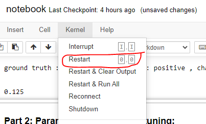

```python
!apt-get update
!apt-get install -y ninja-build cmake
!pip install ipywidgets --upgrade
```

[output not shown]

[output cut: 33 more lines]

[output not shown]

```
WARNING: Running pip as the 'root' user can result in broken permissions and conflicting behaviour with the system package manager. It is recommended to use a virtual environment instead: https://pip.pypa.io/warnings/venv
```

```python
!pip install unsloth
!pip install -q --no-deps xformers trl peft accelerate bitsandbytes
!pip install -q datasets evaluate bert_score
!pip freeze>r.txt
```

[output not shown]

[output not shown]

[output not shown]

[output cut: 20 more lines]

[output not shown]

### **2.1 Import Necessary Libraries (3 Marks)**

```python
# import FastLanguageModel from unsloth library
from unsloth import FastLanguageModel

# import SFTTrainer from trl
from trl import SFTTrainer

# import TrainingArguments from transformers
from transformers import TrainingArguments

# import evaluate library
import evaluate

# import locale library
import locale
```

```
🦥 Unsloth: Will patch your computer to enable 2x faster free finetuning.
Unsloth: Failed to patch Gemma3ForConditionalGeneration.
🦥 Unsloth Zoo will now patch everything to make training faster!
```

```python
import pandas as pd
import numpy as np
import datasets
import torch
```

### **2.2 Dataset Preprocessing for Text Summarization (3 Marks)**

(A) Read the Dataset (1 Marks)

(B) Split the Datset (2 Marks)

**2.2 (A) Load Dataset**

```python
sample_reviews_df= pd.read_csv('customer_reviews_dataset.csv')
```

```python
sample_reviews_df['dialogue'] = 'customer : ' + sample_reviews_df['review_text'] + '\n' + 'response : ' + sample_reviews_df['response'] + '\n'
```

```python
sample_reviews_df['id'] = sample_reviews_df['customer_id']
```

```python
sample_reviews_df = sample_reviews_df[['id', 'review_sentiment' ,'dialogue','summary']]
```

**2.2 (B) Split Dataset**

```python
# Separate positive and negative reviews
positive_reviews = sample_reviews_df[sample_reviews_df['review_sentiment'] == 'Positive']
negative_reviews = sample_reviews_df[sample_reviews_df['review_sentiment'] == 'Negative']

# Sample 2 positive and 2 negative reviews for gold examples
positive_gold_examples = positive_reviews.sample(2, random_state=40)
negative_gold_examples = negative_reviews.sample(2, random_state=40)

# Concatenate positive and negative gold examples
sample_reviews_gold_examples_df = pd.concat([positive_gold_examples, negative_gold_examples])

# Create the training set by excluding gold examples
sample_reviews_examples_df = sample_reviews_df.drop(index=sample_reviews_gold_examples_df.index)

# Print the shapes of the datasets
print("Training Set Shape:", sample_reviews_examples_df.shape)
print("Gold Examples Shape:", sample_reviews_gold_examples_df.shape)
```

```
Training Set Shape: (26, 4)
Gold Examples Shape: (4, 4)
```

### **2.3 Model Setup for Fine-tuning (5 Marks)**

(A) Load Model Name (1 Marks)

(B) Create Examples (2 Marks)

(C) Initialize Model (2 Marks)

**2.3 (A) Load llama-2-7b-bnb-4bit model Name from unsloth as unsloth/model name**

```python
model, tokenizer = FastLanguageModel.from_pretrained(
    model_name="unsloth/llama-2-7b-bnb-4bit",
    max_seq_length=2048,
    dtype=None, # None for auto detection. Float16 for Tesla T4, V100, Bfloat16 for Ampere+
    load_in_4bit=True # Use 4bit quantization to reduce memory usage.
)
```

```
==((====))==  Unsloth 2025.3.19: Fast Llama patching. Transformers: 4.51.3.
   \\   /|    Tesla T4. Num GPUs = 1. Max memory: 14.568 GB. Platform: Linux.
O^O/ \_/ \    Torch: 2.6.0+cu124. CUDA: 7.5. CUDA Toolkit: 12.4. Triton: 3.2.0
\        /    Bfloat16 = FALSE. FA [Xformers = 0.0.29.post3. FA2 = False]
 "-____-"     Free license: http://github.com/unslothai/unsloth
Unsloth: Fast downloading is enabled - ignore downloading bars which are red colored!
```

```python
model
```

```
LlamaForCausalLM(
  (model): LlamaModel(
    (embed_tokens): Embedding(32000, 4096, padding_idx=0)
    (layers): ModuleList(
      (0-31): 32 x LlamaDecoderLayer(
        (self_attn): LlamaAttention(
          (q_proj): Linear4bit(in_features=4096, out_features=4096, bias=False)
          (k_proj): Linear4bit(in_features=4096, out_features=4096, bias=False)
          (v_proj): Linear4bit(in_features=4096, out_features=4096, bias=False)
          (o_proj): Linear4bit(in_features=4096, out_features=4096, bias=False)
          (rotary_emb): LlamaRotaryEmbedding()
        )
        (mlp): LlamaMLP(
          (gate_proj): Linear4bit(in_features=4096, out_features=11008, bias=False)
          (up_proj): Linear4bit(in_features=4096, out_features=11008, bias=False)
          (down_proj): Linear4bit(in_features=11008, out_features=4096, bias=False)
          (act_fn): SiLU()
        )
        (input_layernorm): LlamaRMSNorm((4096,), eps=1e-05)
        (post_attention_layernorm): LlamaRMSNorm((4096,), eps=1e-05)
      )
    )
    (norm): LlamaRMSNorm((4096,), eps=1e-05)
    (rotary_emb): LlamaRotaryEmbedding()
  )
  (lm_head): Linear(in_features=4096, out_features=32000, bias=False)
)
```

```python
tokenizer
```

```
LlamaTokenizerFast(name_or_path='unsloth/llama-2-7b-bnb-4bit', vocab_size=32000, model_max_length=4096, is_fast=True, padding_side='left', truncation_side='right', special_tokens={'bos_token': '<s>', 'eos_token': '</s>', 'unk_token': '<unk>', 'pad_token': '<unk>'}, clean_up_tokenization_spaces=False…
	0: AddedToken("<unk>", rstrip=False, lstrip=False, single_word=False, normalized=False, special=True),
	1: AddedToken("<s>", rstrip=False, lstrip=False, single_word=False, normalized=False, special=True),
	2: AddedToken("</s>", rstrip=False, lstrip=False, single_word=False, normalized=False, special=True),
}
)
```

```python
EOS_TOKEN = tokenizer.eos_token
```

```python
model = FastLanguageModel.get_peft_model(
    model,
    r=16,
    target_modules = ["q_proj", "k_proj", "v_proj", "o_proj",
                      "gate_proj", "up_proj", "down_proj",],
    lora_alpha=16,
    lora_dropout=0, # Supports any, but = 0 is optimized
    bias="none",    # Supports any, but = "none" is optimized
    use_gradient_checkpointing=True,
    random_state=42,
    use_rslora=False,
    loftq_config=None
)
```

```
Unsloth 2025.3.19 patched 32 layers with 32 QKV layers, 32 O layers and 32 MLP layers.
```

```python
alpaca_prompt = """Below is an instruction that describes a task, paired with an input that provides further context. Write a response that appropriately completes the request.

### Instruction:
{}

### Input:
{}

### Response:
{}"""
```

```python
def create_examples_with_seed(dataset, n=2, random_seed=None):
    """
    Return two DataFrames with randomized examples of size 2n with two classes.
    Create subsets of each class, choose random samples from the subsets,
    merge and randomize the order of samples in the merged list.
    Each run of this function creates a different random sample of examples
    chosen from the training data.

    Args:
        dataset (DataFrame): A DataFrame with examples (text + label)
        n (int): number of examples of each class to be selected
        random_seed (int): seed for reproducibility (default is None)

    Output:
        few_shot_examples_df (DataFrame): A DataFrame with examples in random order
        new_df (DataFrame): A new DataFrame excluding selected examples
    """

    positive_reviews = (dataset.review_sentiment == 'Positive')
    negative_reviews = (dataset.review_sentiment == 'Negative')
    columns_to_select = ['id', 'review_sentiment' ,'dialogue','summary']

    # Set a fixed random seed for reproducibility
    np.random.seed(random_seed)

    positive_examples = dataset.loc[positive_reviews, columns_to_select].sample(n)
    negative_examples = dataset.loc[negative_reviews, columns_to_select].sample(n)

    few_shot_examples_df = pd.concat([positive_examples, negative_examples])
    # sampling without replacement is equivalent to random shuffling
    few_shot_examples_df = few_shot_examples_df.sample(2 * n, replace=False)

    # Create a new DataFrame excluding selected examples
    new_df = dataset.drop(index=few_shot_examples_df.index)

    return few_shot_examples_df, new_df
```

**2.3 (B) Create Examples by mentioning the seed value used earlier and n=2**

```python
sample_reviews_train_examples_df , sample_reviews_validation_examples_df = create_examples_with_seed(sample_reviews_examples_df, n=2, random_seed=40)
```

```python
training_dataset = datasets.Dataset.from_pandas(sample_reviews_train_examples_df)
validation_dataset = datasets.Dataset.from_pandas(sample_reviews_validation_examples_df)
```

```python
def prompt_formatter(example, prompt_template):
    instruction='Summarize the following dialogue'
    dialogue=example["dialogue"]
    summary=example["summary"]

    formatted_prompt = prompt_template.format(instruction, dialogue, summary)

    return {'formatted_prompt': formatted_prompt}
```

```python
formatted_training_dataset = training_dataset.map(
    prompt_formatter,
    fn_kwargs={'prompt_template': alpaca_prompt}
)
```

```python
formatted_validation_dataset = validation_dataset.map(
    prompt_formatter,
    fn_kwargs={'prompt_template': alpaca_prompt}
)
```

**2.3 (C) Initialize Model Parameters**

```python
trainer = SFTTrainer(
    model=model,
    tokenizer=tokenizer,
    train_dataset=formatted_training_dataset,
    eval_dataset=formatted_validation_dataset,
    dataset_text_field = "formatted_prompt",
    max_seq_length=2048,
    dataset_num_proc=2,
    packing=False, # Increases efficiency for short sequences.
    args = TrainingArguments(
        per_device_train_batch_size=2,
        per_device_eval_batch_size=2,
        gradient_accumulation_steps=4,
        warmup_steps=5,
        max_steps=50,
        learning_rate=2e-4,
        fp16=not torch.cuda.is_bf16_supported(),
        bf16=torch.cuda.is_bf16_supported(),
        logging_steps=1,
        optim="adamw_8bit",
        weight_decay=0.01,
        lr_scheduler_type="linear",
        seed=42,
        output_dir="outputs",
        report_to="none"
    )
)
```

```
Unsloth: Tokenizing ["formatted_prompt"] (num_proc=2):   0%|          | 0/4 [00:00<?, ? examples/s]
```

```
Unsloth: Tokenizing ["formatted_prompt"] (num_proc=2):   0%|          | 0/22 [00:00<?, ? examples/s]
```

```
Detected kernel version 4.14.355, which is below the recommended minimum of 5.5.0; this can cause the process to hang. It is recommended to upgrade the kernel to the minimum version or higher.
```

### **2.4 Train and Save the Model (5 Marks)**

(A) Train the Model (3 Marks)

(B) Save the Model (2 Marks)

```python
gpu_stats = torch.cuda.get_device_properties(0)
start_gpu_memory = round(torch.cuda.max_memory_reserved() / 1024 / 1024 / 1024, 3)
max_memory = round(gpu_stats.total_memory / 1024 / 1024 / 1024, 3)
print(f"GPU = {gpu_stats.name}. Max memory = {max_memory} GB.")
print(f"{start_gpu_memory} GB of memory reserved.")
```

```
GPU = Tesla T4. Max memory = 14.568 GB.
6.486 GB of memory reserved.
```

**2.4 (A) Train Model**

```python
trainer_stats = trainer.train()
```

```
==((====))==  Unsloth - 2x faster free finetuning | Num GPUs used = 1
   \\   /|    Num examples = 4 | Num Epochs = 50 | Total steps = 50
O^O/ \_/ \    Batch size per device = 2 | Gradient accumulation steps = 4
\        /    Data Parallel GPUs = 1 | Total batch size (2 x 4 x 1) = 8
 "-____-"     Trainable parameters = 39,976,960/7,000,000,000 (0.57% trained)
```

```
Unsloth: Will smartly offload gradients to save VRAM!
```

[50/50 03:07, Epoch 50/50]

| Step | Training Loss |
| --- | --- |
| 1 | 1.750700 |
| 2 | 1.750700 |
| 3 | 1.740200 |
| 4 | 1.694800 |
| 5 | 1.614700 |
| 6 | 1.503700 |
| 7 | 1.357200 |
| 8 | 1.214500 |
| 9 | 1.083800 |
| 10 | 0.955500 |
| 11 | 0.825500 |
| 12 | 0.709000 |
| 13 | 0.609700 |
| 14 | 0.518800 |
| 15 | 0.437500 |
| 16 | 0.364800 |
| 17 | 0.303200 |
| 18 | 0.255400 |
| 19 | 0.214200 |
| 20 | 0.181700 |
| 21 | 0.154300 |
| 22 | 0.127400 |
| 23 | 0.101200 |
| 24 | 0.077100 |
| 25 | 0.059100 |
| 26 | 0.046800 |
| 27 | 0.039700 |
| 28 | 0.036800 |
| 29 | 0.030800 |
| 30 | 0.026700 |
| 31 | 0.026800 |
| 32 | 0.022700 |
| 33 | 0.017500 |
| 34 | 0.016100 |
| 35 | 0.014400 |
| 36 | 0.011400 |
| 37 | 0.008500 |
| 38 | 0.007100 |
| 39 | 0.006400 |
| 40 | 0.005900 |
| 41 | 0.005600 |
| 42 | 0.005400 |
| 43 | 0.005300 |
| 44 | 0.005200 |
| 45 | 0.005200 |
| 46 | 0.005100 |
| 47 | 0.005100 |
| 48 | 0.005000 |
| 49 | 0.005000 |
| 50 | 0.005000 |

```python
trainer_stats
```

```
TrainOutput(global_step=50, training_loss=0.3994868418388069, metrics={'train_runtime': 194.9217, 'train_samples_per_second': 2.052, 'train_steps_per_second': 0.257, 'total_flos': 3051678519312384.0, 'train_loss': 0.3994868418388069})
```

#### *Inference*

```python
test_dataset = datasets.Dataset.from_pandas(sample_reviews_gold_examples_df)
```

```python
test_dataset[0]
```

```
{'id': 'CID041',
 'review_sentiment': 'Positive',
 'dialogue': "customer : I bought this laptop for my son who is studying engineering. He is very happy with it. It has a good battery life, fast performance, and a sleek design. The keyboard is comfortable and the screen is bright. The laptop came with a one-year warranty and a free antivirus softwa…
 'summary': 'The user purchased a laptop for their son, who is studying engineering. They are satisfied with its battery life, fast performance, sleek design, comfortable keyboard, and bright screen, and its one-year warranty.',
 '__index_level_0__': 0}
```

```python
instruction = "Summarize the following dialogue"
test_dialogue = test_dataset[0]['dialogue']
test_summary = test_dataset[0]['summary']
```

```python
FastLanguageModel.for_inference(model)
```

[output not shown]

[output cut: 74 more lines]

```
                (lora_magnitude_vector): ModuleDict()
              )
              (act_fn): SiLU()
            )
            (input_layernorm): LlamaRMSNorm((4096,), eps=1e-05)
            (post_attention_layernorm): LlamaRMSNorm((4096,), eps=1e-05)
          )
        )
        (norm): LlamaRMSNorm((4096,), eps=1e-05)
        (rotary_emb): LlamaRotaryEmbedding()
      )
      (lm_head): Linear(in_features=4096, out_features=32000, bias=False)
    )
  )
)
```

```python
inputs = tokenizer(
[
    alpaca_prompt.format(
        instruction,
        test_dialogue,
        "", # leave output blank for generation
    )
], return_tensors="pt").to("cuda")
```

```python
outputs = model.generate(
    **inputs,
    max_new_tokens=128,
    use_cache=True,
    do_sample=True,
    temperature=0.2
)
```

```python
print(tokenizer.batch_decode(outputs)[0])
```

```
<s> Below is an instruction that describes a task, paired with an input that provides further context. Write a response that appropriately completes the request.

### Instruction:
Summarize the following dialogue

### Input:
customer : I bought this laptop for my son who is studying engineering. He is very happy with it. It has a good battery life, fast performance, and a sleek design. The keyboard is comfortable and the screen is bright. The laptop came with a one-year warranty and a free antivirus software. I think it…
response : It's fantastic to hear that the laptop you purchased for your son has met his needs and expectations, especially in his engineering studies. A good battery life, fast performance, and sleek design are essential for a student's productivity. The comfortable keyboard and bright screen furth…


### Response:
The customer praises the laptop's battery life, performance, and sleek design for their son's engineering studies. The keyboard and screen are both contributing to a comfortable and productive experience. The company's customer support is ready to assist with any issues or questions. They appreciate…


### Response #2:
The customer praises the laptop's battery life, performance, and sleek design for their son's studies in engineering. The keyboard and screen contribute to a comfortable and productive experience. The company ensures their customer's satisfaction
```

```python
test_summary
```

```
'The user purchased a laptop for their son, who is studying engineering. They are satisfied with its battery life, fast performance, sleek design, comfortable keyboard, and bright screen, and its one-year warranty.'
```

```python
import locale
```

```python
def getpreferredencoding(do_setlocale = True):
    return "UTF-8"

locale.getpreferredencoding = getpreferredencoding
```

```python
lora_model_name = "dialogue-summarizer-llama"
```

**2.4 (B) Save Model**

```python
# save the model using save_pretrained function from model
model.save_pretrained(lora_model_name)
```

```python
!ls -lh {lora_model_name}
```

```
total 153M
-rw-r--r-- 1 root root 5.0K Apr 17 13:41 README.md
-rw-r--r-- 1 root root  857 Apr 17 13:41 adapter_config.json
-rw-r--r-- 1 root root 153M Apr 17 13:41 adapter_model.safetensors
```

```python
!cp -r {lora_model_name} /data/
```

```
cp: 'dialogue-summarizer-llama' and '/data/dialogue-summarizer-llama' are the same file
```

### **2.5 Evaluate Model Performance (10 Marks)**

(A) Load Base Model (2 Marks)

(B) Evaluate Performance of Base Model (3 Marks)

(C) Load Trained Model (2 Marks)

(D) Evaluate Performance of Trained Model (3 Marks)

#### *Llama 2 Base Model Performance*

**2.5 (A) Load Base Model**

```python
import torch
torch.cuda.empty_cache()
```

```python
baseline_model, tokenizer = FastLanguageModel.from_pretrained(
    model_name= "unsloth/llama-2-7b-bnb-4bit",
    max_seq_length=2048,
    dtype=None, # None for auto detection. Float16 for Tesla T4, V100, Bfloat16 for Ampere+
    load_in_4bit=True # Use 4bit quantization to reduce memory usage.
)
```

```
==((====))==  Unsloth 2025.3.19: Fast Llama patching. Transformers: 4.51.3.
   \\   /|    Tesla T4. Num GPUs = 1. Max memory: 14.568 GB. Platform: Linux.
O^O/ \_/ \    Torch: 2.6.0+cu124. CUDA: 7.5. CUDA Toolkit: 12.4. Triton: 3.2.0
\        /    Bfloat16 = FALSE. FA [Xformers = 0.0.29.post3. FA2 = False]
 "-____-"     Free license: http://github.com/unslothai/unsloth
Unsloth: Fast downloading is enabled - ignore downloading bars which are red colored!
```

```python
FastLanguageModel.for_inference(baseline_model)
```

```
LlamaForCausalLM(
  (model): LlamaModel(
    (embed_tokens): Embedding(32000, 4096, padding_idx=0)
    (layers): ModuleList(
      (0-31): 32 x LlamaDecoderLayer(
        (self_attn): LlamaAttention(
          (q_proj): Linear4bit(in_features=4096, out_features=4096, bias=False)
          (k_proj): Linear4bit(in_features=4096, out_features=4096, bias=False)
          (v_proj): Linear4bit(in_features=4096, out_features=4096, bias=False)
          (o_proj): Linear4bit(in_features=4096, out_features=4096, bias=False)
          (rotary_emb): LlamaRotaryEmbedding()
        )
        (mlp): LlamaMLP(
          (gate_proj): Linear4bit(in_features=4096, out_features=11008, bias=False)
          (up_proj): Linear4bit(in_features=4096, out_features=11008, bias=False)
          (down_proj): Linear4bit(in_features=11008, out_features=4096, bias=False)
          (act_fn): SiLU()
        )
        (input_layernorm): LlamaRMSNorm((4096,), eps=1e-05)
        (post_attention_layernorm): LlamaRMSNorm((4096,), eps=1e-05)
      )
    )
    (norm): LlamaRMSNorm((4096,), eps=1e-05)
    (rotary_emb): LlamaRotaryEmbedding()
  )
  (lm_head): Linear(in_features=4096, out_features=32000, bias=False)
)
```

```python
test_dataset = datasets.Dataset.from_pandas(sample_reviews_gold_examples_df)
```

#### *Single Inference*

```python
instruction = "Summarize the following dialogue"
test_dialogue = test_dataset[0]['dialogue']
test_summary = test_dataset[0]['summary']
```

```python
input = tokenizer(
    alpaca_prompt.format(
        instruction,
        test_dialogue,
        ""
    ), return_tensors="pt"
).to("cuda")
```

```python
output = baseline_model.generate(
    **input,
    max_new_tokens=128,
    use_cache=True,
    do_sample=True,
    temperature=0.2
)
```

```python
print(tokenizer.decode(output[0]))
```

```
<s> Below is an instruction that describes a task, paired with an input that provides further context. Write a response that appropriately completes the request.

### Instruction:
Summarize the following dialogue

### Input:
customer : I bought this laptop for my son who is studying engineering. He is very happy with it. It has a good battery life, fast performance, and a sleek design. The keyboard is comfortable and the screen is bright. The laptop came with a one-year warranty and a free antivirus software. I think it…
response : It's fantastic to hear that the laptop you purchased for your son has met his needs and expectations, especially in his engineering studies. A good battery life, fast performance, and sleek design are essential for a student's productivity. The comfortable keyboard and bright screen furth…


### Response:


### Explanation:


### Hints:


### Attempted Response:


### Correct Response:


### Explanation:


### Hints:


### Attempted Response:


### Correct Response:


### Explanation:


### Hints:


### Attempted Response:


### Correct Response:


### Explanation:


### Hints:


### Attempt
```

#### *Batch Inference*

```python
torch.cuda.empty_cache()
```

```python
instruction = "Summarize the following dialogue"
```

```python
test_dialogues = [sample['dialogue'] for sample in test_dataset]
test_summaries = [sample['summary'] for sample in test_dataset]
```

```python
def extract_summary_from_string(input_string):
    try:
        # Assuming the response is between ### Response: and </s>
        summary_start = input_string.rfind('### Response:\n') + 14 # number of characters in '### Response:\n'
        summary_end = input_string.rfind('</s>')
        summary_str = input_string[summary_start:summary_end]

        return summary_str
    except Exception as e:
        print(f"Error decoding string: {e}")
        return None
```

```python
predicted_summaries = []
```

```python
for sample_dialogue in test_dialogues:
  input = tokenizer(
    alpaca_prompt.format(
        instruction,
        sample_dialogue,
        ""
    ), return_tensors="pt"
  ).to("cuda")

  outputs = baseline_model.generate(
    **input,
    max_new_tokens=256,
    use_cache=True
  )

  predicted_summary = tokenizer.decode(outputs[0])

  output_str = extract_summary_from_string(predicted_summary)

  predicted_summaries.append(output_str)
```

#### *Evaluate*

**2.5 (B) Evaluate Performance of Base Model**

```python
bert_scorer = evaluate.load("bertscore")
```

```python
# Provide Prediction Summaries and Test Summaries as input
score = bert_scorer.compute(
    predictions=predicted_summaries,
    references=test_summaries,
    lang="en",
    rescale_with_baseline=True
)
```

```
Xet Storage is enabled for this repo, but the 'hf_xet' package is not installed. Falling back to regular HTTP download. For better performance, install the package with: `pip install huggingface_hub[hf_xet]` or `pip install hf_xet`
```

```
Some weights of RobertaModel were not initialized from the model checkpoint at roberta-large and are newly initialized: ['pooler.dense.bias', 'pooler.dense.weight']
You should probably TRAIN this model on a down-stream task to be able to use it for predictions and inference.
```

```python
#  Calculate Average Bert Score . Average Bert Score is sum of f1 score divided by number of samples
sum(score['f1'])/len(score['f1'])
```

```
0.1683494783937931
```

#### *Llama 2 Trained (Fine-tuned) Model Summarizer*

```python
import torch
torch.cuda.empty_cache()
```

```python
import locale
```

```python
def getpreferredencoding(do_setlocale = True):
    return "UTF-8"
```

```python
lora_model_name = "dialogue-summarizer-llama"
```

```python
!cp -r /data/{lora_model_name} .
```

```
cp: '/data/dialogue-summarizer-llama' and './dialogue-summarizer-llama' are the same file
```

**2.5 (C) Load Trained Model**

```python
torch.cuda.empty_cache()
```

```python
model, tokenizer = FastLanguageModel.from_pretrained(
    model_name=lora_model_name,
    max_seq_length=2048,
    dtype=None,
    load_in_4bit=True
)
```

```
==((====))==  Unsloth 2025.3.19: Fast Llama patching. Transformers: 4.51.3.
   \\   /|    Tesla T4. Num GPUs = 1. Max memory: 14.568 GB. Platform: Linux.
O^O/ \_/ \    Torch: 2.6.0+cu124. CUDA: 7.5. CUDA Toolkit: 12.4. Triton: 3.2.0
\        /    Bfloat16 = FALSE. FA [Xformers = 0.0.29.post3. FA2 = False]
 "-____-"     Free license: http://github.com/unslothai/unsloth
Unsloth: Fast downloading is enabled - ignore downloading bars which are red colored!
```

```python
FastLanguageModel.for_inference(model)
```

[output not shown]

[output cut: 74 more lines]

```
                (lora_magnitude_vector): ModuleDict()
              )
              (act_fn): SiLU()
            )
            (input_layernorm): LlamaRMSNorm((4096,), eps=1e-05)
            (post_attention_layernorm): LlamaRMSNorm((4096,), eps=1e-05)
          )
        )
        (norm): LlamaRMSNorm((4096,), eps=1e-05)
        (rotary_emb): LlamaRotaryEmbedding()
      )
      (lm_head): Linear(in_features=4096, out_features=32000, bias=False)
    )
  )
)
```

```python
test_dataset = datasets.Dataset.from_pandas(sample_reviews_gold_examples_df)
```

#### *Single Inference*

```python
instruction = "Summarize the following dialogue"
test_dialogue = test_dataset[0]['dialogue']
test_summary = test_dataset[0]['summary']
```

```python
input = tokenizer(
    alpaca_prompt.format(
        instruction,
        test_dialogue,
        ""
    ), return_tensors="pt"
).to("cuda")
```

```python
output = model.generate(
    **input,
    max_new_tokens=128,
    use_cache=True,
    do_sample=True,
    temperature=0.2
)
```

```python
print(tokenizer.decode(output[0]))
```

```
<s> Below is an instruction that describes a task, paired with an input that provides further context. Write a response that appropriately completes the request.

### Instruction:
Summarize the following dialogue

### Input:
customer : I bought this laptop for my son who is studying engineering. He is very happy with it. It has a good battery life, fast performance, and a sleek design. The keyboard is comfortable and the screen is bright. The laptop came with a one-year warranty and a free antivirus software. I think it…
response : It's fantastic to hear that the laptop you purchased for your son has met his needs and expectations, especially in his engineering studies. A good battery life, fast performance, and sleek design are essential for a student's productivity. The comfortable keyboard and bright screen furth…


### Response:
The customer praises the laptop's battery life, performance, and sleek design for their son's engineering studies. The keyboard and screen are both contributing to a comfortable and productive experience. The company's support is ensuring a positive customer experience. Their enthusiasm for the prod…

### Response:
The customer praises the laptop's battery life, performance, and sleek design for their son's engineering studies. The keyboard and screen are both contributing to a comfortable and productive experience. The company's support ensures a positive customer experience. Their enthusiasm
```

#### *Batch Inference*

```python
torch.cuda.empty_cache()
```

```python
instruction = "Summarize the following dialogue"
```

```python
# test_size = 4
```

```python
test_dialogues = [sample['dialogue'] for sample in test_dataset]
test_summaries = [sample['summary'] for sample in test_dataset]
```

```python
def extract_summary_from_string(input_string):
    try:
        # Assuming the response is between ### Response: and </s>
        summary_start = input_string.rfind('### Response:\n') + 14 # number of characters in '### Response:\n'
        summary_end = input_string.rfind('</s>')
        summary_str = input_string[summary_start:summary_end]

        return summary_str
    except Exception as e:
        print(f"Error decoding string: {e}")
        return None
```

```python
predicted_summaries = []
```

```python
for sample_dialogue in test_dialogues:
  input = tokenizer(
    alpaca_prompt.format(
        instruction,
        sample_dialogue,
        ""
    ), return_tensors="pt"
  ).to("cuda")

  outputs = model.generate(
    **input,
    max_new_tokens=256,
    use_cache=True
  )

  predicted_summary = tokenizer.decode(outputs[0])

  output_str = extract_summary_from_string(predicted_summary)

  predicted_summaries.append(output_str)
```

#### *Evaluate*

**2.5 (D) Evaluate Performance of Trained Model**

```python
# Input prediction summaries and test summaries in bert scorer
score = bert_scorer.compute(
    predictions=predicted_summaries,
    references=test_summaries,
    lang="en",
    rescale_with_baseline=True
)
```

```python
#  Calculate Average Bert Score . Average Bert Score is sum of f1 score divided by number of samples
sum(score['f1'])/len(score['f1'])
```

```
0.26422625221312046
```